# Intro to Bayesian software

## Goals

- Introduce you to Bayesian inference
- Learn syntax for Bayesian software (JAGS)
- Run model and assess output
- Increase awareness of other software (Nimble, Stan)

## Outline (Today)

- Probability review
  - random variables, distributions, models, inference
- Bayesian theory
  - Bayes theorem, priors, MCMC
- Software: JAGS
  - model syntax, data and initial values, MCMC settings, running the model

## Outline (Tomorrow)

- Model output
  - structure
  - convergence
  - summarizing
  - inference & visuals
- Other software
  - Rstan, Nimble

## Probability

- Random variable: process of assigning numerical values to the outcome of random events
  - Notation: \(X\)
- Random variate: specific numerical outcome (data!)
  - Notation: \(x\)

## Probability

- Probability distribution: common description of possible outcomes of a random variable
  - \(P(X = x)\) when \(x_1 = 4, x_2 = 2, ..., x_n\)
- Density/mass function: function containing input parameters and outputs probability
  - Notation: \(f_X(x|\boldsymbol{\theta})\) OR \(x_i \sim f(\theta)\)
  - PDF for Normal distribution: \[f_X(x|\mu,\sigma)=\frac{1}{\sqrt{2\pi\sigma^2}}e^{-\frac{(x-\mu)^2}{2\sigma^2}}\] \[ x \sim Norm(\mu, \sigma)\]

## Probability example

Calculate probability that a random variable is equal to certain outcomes (random variate)

```r
mean <- 5; sd <- 2; outcome <- c(-0.7, 1.1, 2.3, 5.5)
```

\[f_X(x = -0.7|\mu = 5,\sigma = 2)=\frac{1}{\sqrt{2\pi2^2}}e^{-\frac{(-0.7-5)^2}{2\times2^2}}\]

```r
(1/sqrt(2*pi*sd^2))*exp(-((outcome - mean)^2/(2*sd^2)))
```

```
## [1] 0.003436383 0.029797353 0.080191664 0.193334058
```

```r
dnorm(outcome, mean, sd)
```

```
## [1] 0.003436383 0.029797353 0.080191664 0.193334058
```

## Probability example

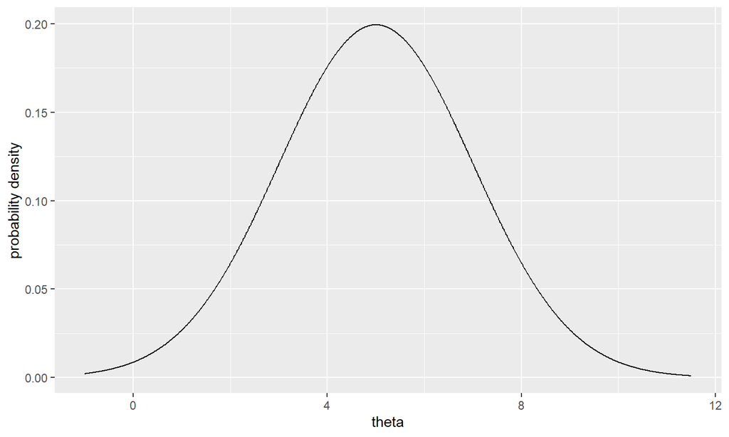

## Probability example

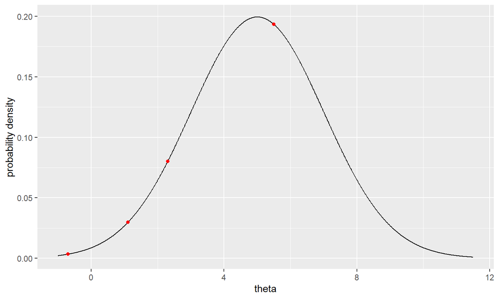

## Linear models

- Parameters within distributions are described with linear equation and link functions
  - \(f_X(x|\theta)\) OR \(x \sim f(\theta)\)
  - \(g(\theta)=\alpha + \beta\times COVARIATE\)
  - t-test, anova, regression, ancova
- General linear models (normal distribution)
- Generalized linear models (other distributions)
- Model structure is separate from inference
- Bayesian statistics is about inference

## Inference

What to do when parameters are unknown?

- Frequentist (eg, Maximum likelihood estimation [MLE])
- Bayesian

## Frequentist

- Probability statement is made about the data
  - \(P(X = x|\boldsymbol{\theta})\)
- Parameter values are fixed
- Data are independent random variates (ie, joint probability)
  - \(f_X(\boldsymbol{x}|\mu,\sigma)=f_X(x_1|\mu,\sigma)\times f_X(x_2|\mu,\sigma)\times ... f_X(x_n|\mu,\sigma)\)
- Joint probability = likelihood
  - Likelihood of being true fixed parameter values given our observed data
  - \(f_X(\boldsymbol{x}|\mu,\sigma) = L(\mu,\sigma|\boldsymbol{x})\)

## Frequentist

- Estimate unknown parameters by minimizing negative log-likelihood

\[\tiny L(\boldsymbol{\theta}|\boldsymbol{x})=\prod_{i=1}^{i=n}{f_X(\boldsymbol{x}|\boldsymbol{\theta})}\] \[\tiny l(\boldsymbol{\theta}|\boldsymbol{x})=log(\prod_{i=1}^{i=n}{f_X(x_i|\boldsymbol{\theta})})\] \[\tiny =log(f_X(x_1|\boldsymbol{\theta})\times f_X(x_2|\boldsymbol{\theta})\times ... f_X(x_n|\boldsymbol{\theta}))\] \[\tiny =log(f_X(x_1|\boldsymbol{\theta}))+log(f_X(x_2|\boldsymbol{\theta}))+ ... log(f_X(x_n|\boldsymbol{\theta}))\] \[\tiny \sum_{i=1}^{i=n}{log(f_X(x_i|\boldsymbol{\theta}))}\] \[\tiny nll=-\sum_{i=1}^{i=n}{log(f_X(x_i|\boldsymbol{\theta}))}\]

## Frequentist

```r
outcome <- c(outcome, rnorm(100, mean, sd))

nll <- function(x) {
  return(-1 * sum(dnorm(x = outcome, mean = x[1], sd = x[2], log = TRUE)))
}
optim(par = c(0, 1), fn = nll)$par
```

```
## [1] 4.772579 2.118994
```

`lm(outcome~1)`

```r
c(coef(lm(outcome~1)), sigma(lm(outcome~1))) #Least squares using QR decomposition
```

```
## (Intercept)
##    4.773244    2.129516
```

## Bayesian

- Probability statement is about parameters not data
  - \(P(\boldsymbol{\theta}|X = x)\)
- Data is fixed
- Estimating a posterior distribution
  - \(P(\boldsymbol{\theta}|\boldsymbol{x})\)
- Conditional probability

## Bayes theorem

\[P(\boldsymbol{\theta}|\boldsymbol{x}) = \frac{P(\boldsymbol{x}|\boldsymbol{\theta})P(\boldsymbol{\theta})}{P(\boldsymbol{x})}\] \(P(\boldsymbol{\theta}|\boldsymbol{x})\): Posterior distribution  
\(P(\boldsymbol{x}|\boldsymbol{\theta})\): Likelihood  
\(P(\boldsymbol{\theta})\): Prior distribution  
\(P(\boldsymbol{x})\): Probability of the data

## Likelihood \(P(\boldsymbol{x}\vert\boldsymbol{\theta})\)

We’ve already seen this!

- Probability density or mass function

## Prior distribution \(P(\boldsymbol{\theta})\)

- A distribution that captures prior information about parameter
- Allows formal incorporation of external knowledge
  - Don’t feign stupidity
  - Increased precision
  - Parameter identifiability
- Can be seen as subjective
- Uninformative priors

## Prior example: informative

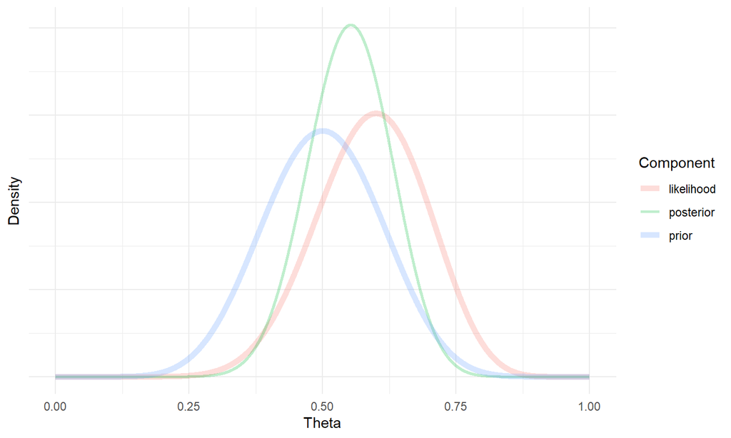

## Prior example: informative

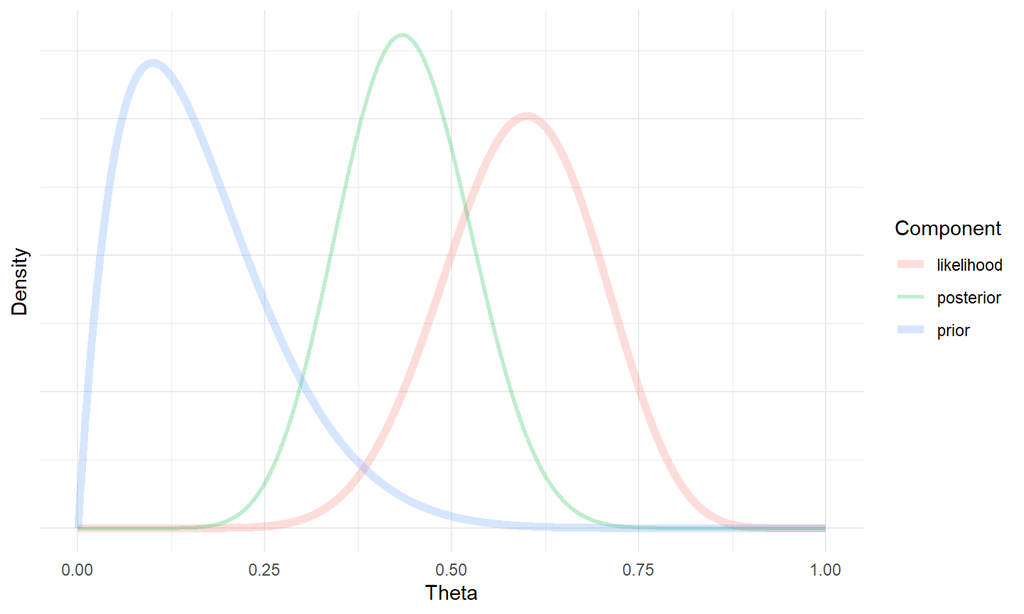

## Prior example: more data

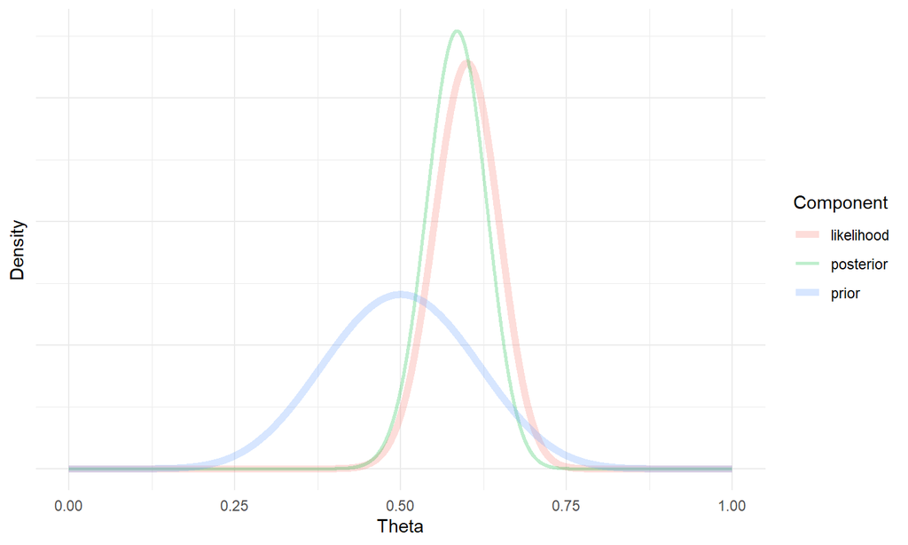

## Prior example: more data

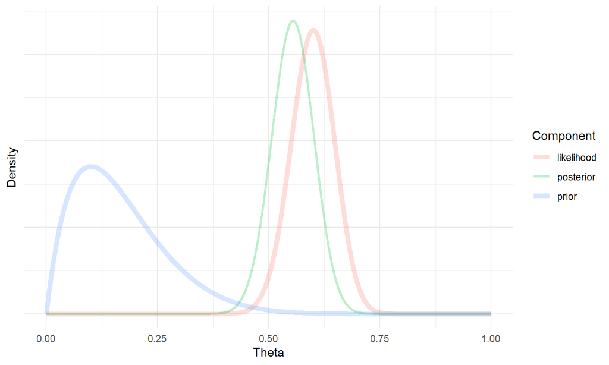

## Prior example: uninformative

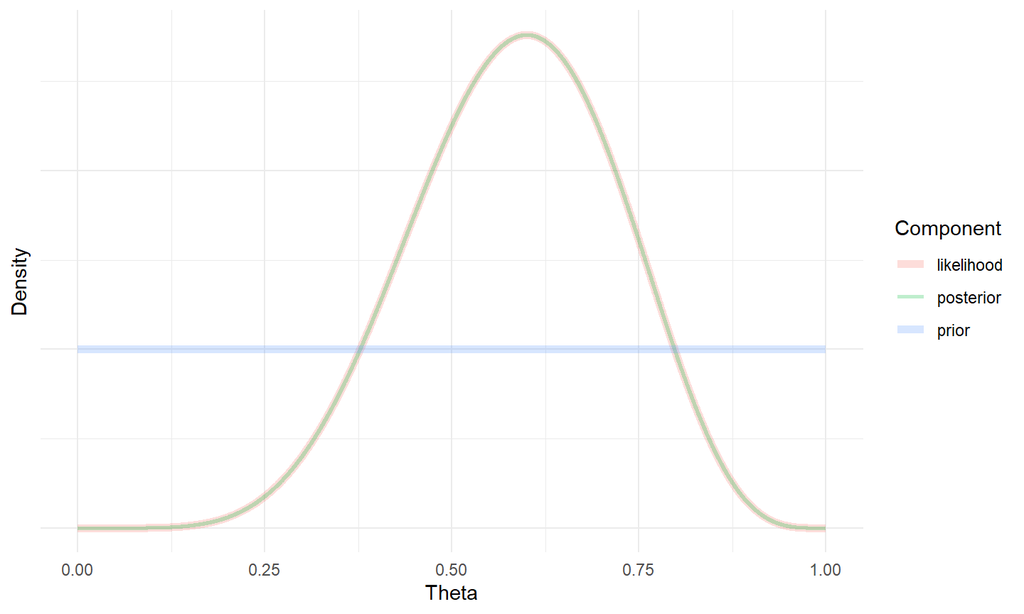

## Probability of the data \(P(\boldsymbol{x})\)

- Normalizing constant (integral equal to 1)
- Intractable integral (\(P(\boldsymbol{x}) = \int{P(\boldsymbol{x}|\boldsymbol{\theta})P(\boldsymbol{\theta})d\boldsymbol{\theta}}\))
- Difficult to find analytical solution (conjugate priors)

## MCMC sampling

- Markov chain Monte Carlo (MCMC)
- Stochastic simulation to draw dependent samples from the posterior distribution
- Approximate posterior (large enough samples/iterations)
- MCMC algorithm
  - Searchers parameter space for stable distribution
  - Updates parameter values using conditional probability
  - Automatic generation of MCMC algorithm by software

## MCMC sampling

[figure not shown]

## Stable distribution

[figure not shown]

## Unconverged model

[figure not shown]

## Bayesian software

- BUGS (Bayesian inference Using Gibbs Sampling)
- JAGS (Just Another Gibbs Sampler)
- Stan
  - rstanarm package
  - brms package
- Nimble

## JAGS

- JAGS (https://sourceforge.net/projects/mcmc-jags/files/latest/download)
- package: jagsUI
- Uses BUGS language
- A series of nodes, relationships, indices, and loops
- Language is declarative (order doesn’t matter)

## Steps

1. Question, study design (model structure), data collection, data cleaning
2. Code JAGS model
- Define likelihood based on model structure
- Choose priors
1. Define initial values
2. Choose MCMC settings
3. Run model
4. Come back tomorrow

## Example

[figure not shown]

```
##                    mpg cyl disp  hp drat    wt  qsec vs am gear carb
## Mazda RX4         21.0   6  160 110 3.90 2.620 16.46  0  1    4    4
## Mazda RX4 Wag     21.0   6  160 110 3.90 2.875 17.02  0  1    4    4
## Datsun 710        22.8   4  108  93 3.85 2.320 18.61  1  1    4    1
## Hornet 4 Drive    21.4   6  258 110 3.08 3.215 19.44  1  0    3    1
## Hornet Sportabout 18.7   8  360 175 3.15 3.440 17.02  0  0    3    2
## Valiant           18.1   6  225 105 2.76 3.460 20.22  1  0    3    1
```

## Example

[figure not shown]

```
## # A tibble: 3 x 2
##     cyl `mean(mpg)`
##   <dbl>       <dbl>
## 1     4        26.7
## 2     6        19.7
## 3     8        15.1
```

## Model structure (Likelihood)

\[y_i \sim Normal(\mu_i, \sigma)\]  
- \(y_i\): mpg for each make & model  
- \(\mu_i\): expected mpg  
- \(\sigma\): standard deviation

## Model structure (Likelihood)

\[\mu_i = \alpha_0 + \alpha_1 \times x_{1,i} + \alpha_2 \times x_{2,i}\]

- \(\alpha_0\): intercept (mean mpg of 4 cyl)
- \(\alpha_1\): effect of 6 cyl (difference in mpg between 4 and 6 cyl)
- \(\alpha_2\): effect of 8 cyl (difference in mpg between 4 and 8 cyl)
- \(x_{1,i}\): dummy vector for 6 cyl (1 for 6 cyl, 0 otherwise)
- \(x_{2,i}\): dummy vector for 8 cyl (1 for 8 cyl, 0 otherwise)

## Model structure (Likelihood)

\[L(\alpha_0,\alpha_1,\alpha_2,\sigma|y_i,x_{1,i},x_{2,i})=\prod_{i=1}^{i=n}{\frac{1}{\sqrt{2\pi\sigma^2}}e^{-\frac{(y_i- (\alpha_0 + \alpha_1 \times x_{1,i} + \alpha_2 \times x_{2,i}))^2}{2\sigma^2}}}\]

## LM code

```r
lm(mpg~as.factor(cyl), data = mtcars)
```

```
##
## Call:
## lm(formula = mpg ~ as.factor(cyl), data = mtcars)
##
## Coefficients:
##     (Intercept)  as.factor(cyl)6  as.factor(cyl)8
##          26.664           -6.921          -11.564
```

```r
confint(lm(mpg~as.factor(cyl), data = mtcars))
```

```
##                     2.5 %    97.5 %
## (Intercept)      24.67608 28.651192
## as.factor(cyl)6 -10.10796 -3.733599
## as.factor(cyl)8 -14.21962 -8.907653
```

## Prior selection

- Often recommended priors for specific parameters
- \(\sigma\): inverse gamma on variance, \(\sigma^2\)
- \(\tau\): precision parameter (inverse of variance, \(1/\sigma^2\))
- \(\alpha_k\): uniformed normal

## Model code

- text file
  - load or sink within script
- 3 components (order doesn’t matter!)
  - Likelihood
  - Prior
  - Derived values

```
model{
##Likelihood
for(i in 1:nobs){
  #likelihood here
}
##Priors
#priors here

##Derived values
#derived values here
}
```

## Model code

```r
cat("
  model{

  }
  ", fill=TRUE, file="Model.txt")
```

## Model code

```r
cat("
  model{

  ##Likelihood
  for(i in 1:nobs){

  }

  }
  ", fill=TRUE, file="Model.txt")
```

## Model code

```r
cat("
  model{

  ##Likelihood
  for(i in 1:nobs){
    y[i] ~ dnorm(mu[i], tau) #likelihood function
  }

  }
  ", fill=TRUE, file="Model.txt")
```

## Model code

```r
cat("
  model{

  ##Likelihood
  for(i in 1:nobs){
    y[i] ~ dnorm(mu[i], tau) #likelihood function
    mu[i] <- alpha0 + alpha1 * x1[i] + alpha2 * x2[i] #linear model of the mean
  }

  }
  ", fill=TRUE, file="Model.txt")
```

## Model code

```r
cat("
  model{

  ##Likelihood
  for(i in 1:nobs){
    y[i] ~ dnorm(mu[i], tau) #likelihood function
    mu[i] <- alpha0 + alpha1 * x1[i] + alpha2 * x2[i] #linear model of the mean
  }

  ##Priors
  alpha0 ~ dnorm(0, 0.001) #mean of 4 cyl
  alpha1 ~ dnorm(0, 0.001) #effect of 6 cyl
  alpha2 ~ dnorm(0, 0.001) #effect of 8 cyl

  }
  ", fill=TRUE, file="Model.txt")
```

## Model code

```r
cat("
  model{

  ##Likelihood
  for(i in 1:nobs){
    y[i] ~ dnorm(mu[i], tau) #likelihood function
    mu[i] <- alpha0 + alpha1 * x1[i] + alpha2 * x2[i] #linear model of the mean
  }

  ##Priors
  alpha0 ~ dnorm(0, 0.001) #mean of 4 cyl
  alpha1 ~ dnorm(0, 0.001) #effect of 6 cyl
  alpha2 ~ dnorm(0, 0.001) #effect of 8 cyl
  tau ~ dgamma(0.001, 0.001) #precision

  }
  ", fill=TRUE, file="Model.txt")
```

## Model code

```r
cat("
  model{

  ##Likelihood
  for(i in 1:nobs){
    y[i] ~ dnorm(mu[i], tau) #likelihood function
    mu[i] <- alpha0 + alpha1 * x1[i] + alpha2 * x2[i] #linear model of the mean
  }

  ##Priors
  alpha0 ~ dnorm(0, 0.001) #mean of 4 cyl
  alpha1 ~ dnorm(0, 0.001) #effect of 6 cyl
  alpha2 ~ dnorm(0, 0.001) #effect of 8 cyl
  tau ~ dgamma(0.001, 0.001) #precision

  ##Derived values
  sigma <- 1/sqrt(tau) #relationship between SD and precision
  mean2 <- alpha0 + alpha1 #mean of 6 cyl
  mean3 <- alpha0 + alpha2 #mean of 8 cyl

  }
  ", fill=TRUE, file="Model.txt")
```

## Compile data

- Data should be in a list
- Names of each list item should match the node name in the model

```r
data <- list(y = mtcars$mpg,
             x1 = ifelse(mtcars$cyl==6,1,0),
             x2 = ifelse(mtcars$cyl==8,1,0),
             nobs = dim(mtcars)[1])
```

## Initial values

- Starting values for each MCMC chain
- If none are supplied model selects values within prior
- Often the culprit for errors
- Provided values should be realistic and mathematically feasible
- Initial values should be a function that returns a list of values

```r
inits <- function(){list(
  alpha0 = runif(1, 10, 33),
  alpha1 = runif(1, -1, 1),
  alpha2 = runif(1, -1, 1),
  tau = runif(1, 0, 1)
)}
```

## Parameters to save

- Parameters we are interested in monitor
- Parameters we need to check for convergence
- Be mindful of memory issues
- Supplied as vector of character values

```r
params <- c("alpha0", "alpha1", "alpha2", "tau", "sigma", "mean2", "mean3")
```

## MCMC settings

- Arguments include
  - Number of MCMC chains to run
  - Number of iterations per chain
  - Length of burn-in (ie, iterations not within stable distribution)
  - Number of iterations to thin (ie, memory issues)
  - Length of adaption (ie, period to determine MCMC step size)
- Tweak to improve computational speed and cost (ie, time and memory)

```r
nc <- 3
ni <- 1100
nb <- 100
nt <- 1
na <- 100
```

## Run model

```r
out <- jags(data = data, model.file = "Model.txt",
              inits = inits, parameters.to.save = params)
```

## Run model

```r
out <- jags(data = data, model.file = "Model.txt",
              inits = inits, parameters.to.save = params,
              n.chains = nc, n.iter = ni, n.burnin = nb,
              n.thin = nt, n.adapt = na)
```

## Run model

```r
out <- jags(data = data, model.file = "Model.txt",
              inits = inits, parameters.to.save = params,
              n.chains = nc, n.iter = ni, n.burnin = nb,
              n.thin = nt, n.adapt = na,
              parallel = FALSE, store.data = FALSE,
              codaOnly = FALSE)
```

## Run model

```
##
## Processing function input.......
##
## Done.
##
##
##
## Adaptive phase, 100 iterations x 3 chains
## If no progress bar appears JAGS has decided not to adapt
##
##
##  Burn-in phase, 100 iterations x 3 chains
##
##
## Sampling from joint posterior, 1000 iterations x 3 chains
##
##
## Calculating statistics.......
##
## Done.
```

## Output

```
## JAGS output for model 'Model.txt', generated by jagsUI.
## Estimates based on 3 chains of 1100 iterations,
## adaptation = 100 iterations (sufficient),
## burn-in = 100 iterations and thin rate = 1,
## yielding 3000 total samples from the joint posterior.
## MCMC ran for 0.002 minutes at time 2020-07-26 23:27:18.
##
##             mean    sd    2.5%     50%   97.5% overlap0 f  Rhat n.eff
## alpha0    26.606 0.981  24.728  26.599  28.600    FALSE 1 1.000  3000
## alpha1    -6.794 1.602  -9.973  -6.816  -3.486    FALSE 1 1.002  1882
## alpha2   -11.475 1.308 -14.078 -11.469  -8.969    FALSE 1 1.000  2456
## tau        0.097 0.025   0.053   0.094   0.153    FALSE 1 1.002   832
## sigma      3.306 0.453   2.559   3.261   4.329    FALSE 1 1.002   967
## mean2     19.813 1.255  17.339  19.806  22.287    FALSE 1 1.001  3000
## mean3     15.131 0.864  13.421  15.129  16.839    FALSE 1 1.000  3000
## deviance 166.733 2.939 163.068 166.074 174.050    FALSE 1 1.000  2835
##
## Successful convergence based on Rhat values (all < 1.1).
## Rhat is the potential scale reduction factor (at convergence, Rhat=1).
## For each parameter, n.eff is a crude measure of effective sample size.
##
## overlap0 checks if 0 falls in the parameter's 95% credible interval.
## f is the proportion of the posterior with the same sign as the mean;
## i.e., our confidence that the parameter is positive or negative.
##
## DIC info: (pD = var(deviance)/2)
## pD = 4.3 and DIC = 171.052
## DIC is an estimate of expected predictive error (lower is better).
```